# Exercise 3

## Steps 1-2

### Background (Brief description of data)

The data is collected during the 2005-2006 school year from two public schools (secondary education) in Portugal. The data include student grades, demographic, social and school related variables, which were collected by using school reports and questionnaires.Among these is also alcohol use. Two datasets are provided regarding the performance in two distinct subjects: Mathematics (mat) and Portuguese language (por). These two have been combined into one file.

Variables G1, G2, G3 are the grades from period 1 to 3 (3 is final grade). Range is from 0-20 and an description of the range of points is in table 1.

#### Table 1.Grades in Portugal (and France)

| Excellent | Good | Satisfactory | Sufficient | Fail |
| --- | --- | --- | --- | --- |
| 16-20p | 14-15p | 12-13p | 10-11p | 0-9p |

```r
#Read the joined student alcohol consumption data into R
alc <- read.delim("~/GitHub/IODS-project/data/alc2018.txt")
dim(alc)
```

```
## [1] 382  35
```

```r
#str(alc)
#Observations: 382
#Variables: 35

#Print out the names of the variables
colnames(alc)
```

```
##  [1] "school"     "sex"        "age"        "address"    "famsize"
##  [6] "Pstatus"    "Medu"       "Fedu"       "Mjob"       "Fjob"
## [11] "reason"     "nursery"    "internet"   "guardian"   "traveltime"
## [16] "studytime"  "failures"   "schoolsup"  "famsup"     "paid"
## [21] "activities" "higher"     "romantic"   "famrel"     "freetime"
## [26] "goout"      "Dalc"       "Walc"       "health"     "absences"
## [31] "G1"         "G2"         "G3"         "alc_use"    "high_use"
```

## Step 3-4

### Personal hypotheses

I chose the following interesting variables from the datset: “sex”, “adress”" (student’s home address type, rural or urban), “famrel” (from 1 - very bad to 5 - excellent) and higher (wants to take higher education (binary: yes or no)). My personal hypotheses regarding these variables and their effect on alcohol consuption is:

Students of male sex, with poor family relationships,that don’t want to make a higher eduction and live in an urban environment drink more alcohol.

### Numerical and graphical exploration of the variables

Table 2a. mean value of familial relationships among high vs low users of alcohol

| high_use | count | mean_famrel |
| --- | --- | --- |
| FALSE | 268 | 4.003731 |
| TRUE | 114 | 3.780702 |

Table 2b. mean value of alcohol use among persons with a rural or urban address

| address | count | mean_alc_use |
| --- | --- | --- |
| R | 81 | 2.086420 |
| U | 301 | 1.835548 |

Table 2c. mean value of alcohol use divided by persons wanting to take higher eduction

| higher | count | mean_alc_use |
| --- | --- | --- |
| no | 18 | 2.361111 |
| yes | 364 | 1.865385 |

Table 2d. mean value of alcohol use divided by male and female

| sex | count | mean_alc_use |
| --- | --- | --- |
| F | 198 | 1.623737 |
| M | 184 | 2.173913 |

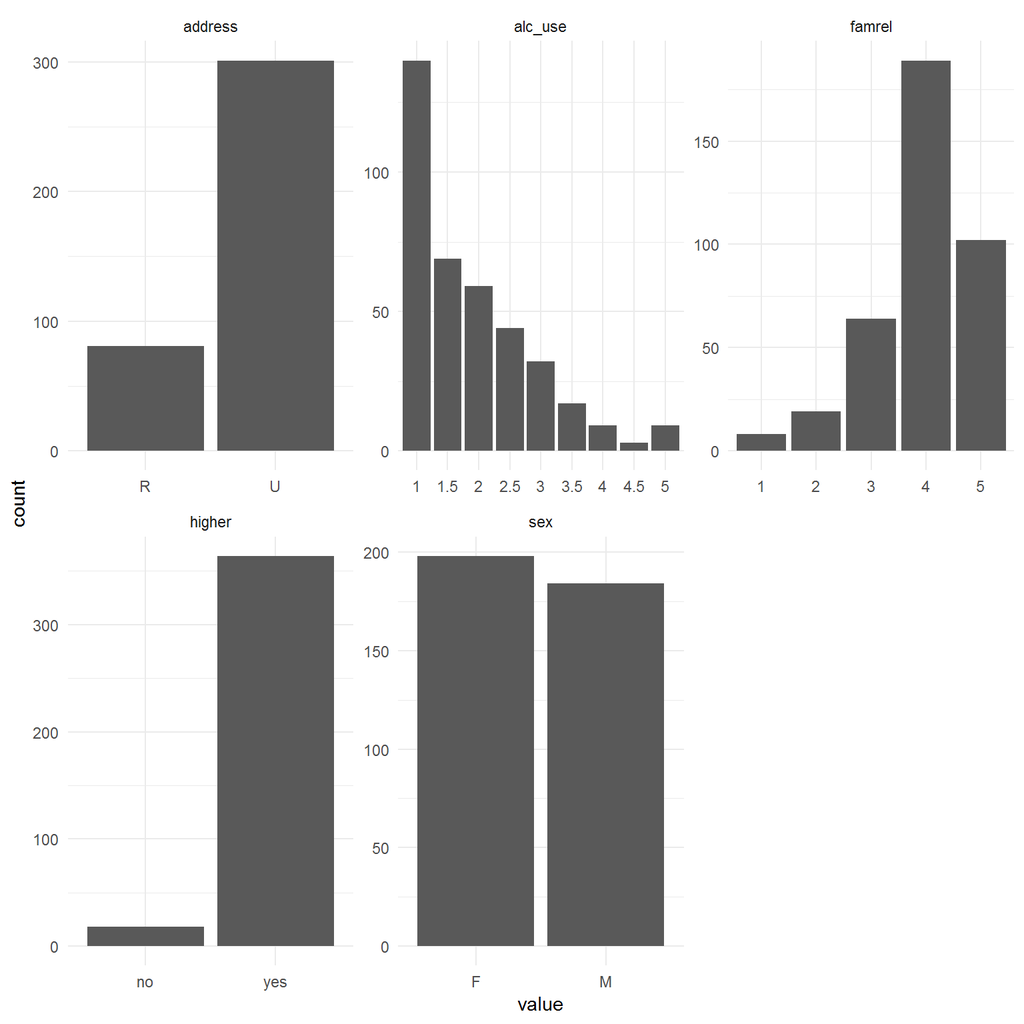

```
## [1] "Figure. 1"
```

[figure not shown]